# Berry Modeling

Tyler Muhly

11/01/2021

## Modeling Berry Occurence and Abundance to Support Timber Supply Review

Here we model occurrence and abundance of berries as a function of stand characteristics to see if we can link to spatial timber supply/forest harvest models.

Berries are important to grizzly bear, and appear to be related to forest stand characteristics, thus forestry may impact distribution and abundance of this important bear food. Can potentially use spatial timber supply models to look at distribution and abundance of berries over space and time under different forest management regimes

## Berry Data

Data on berry shrub occurrence, cover, fruit presence, and fruit abundance was obtained from Clayton Lamb, UBC. The data consists of two datasets, “VegModData_BEC_CL” and “Productivity_Data”.

The “VegModData_BEC_CL” dataset contains berry shrub species occurrence (“species_Occ”) and percent cover (“species_Cover”) data. Data was obtained from biogeoclimatic ecosystem classification (BEC) plots, and plots collected by Clayton Lamb or Mike Proctor.

The “Productivity_Data” dataset contains berry shrub species occurrence (“Species.Present”), shrub percent cover (“Species.Cover”), fruit occurrence (“Fruit.Present”) and fruit percent cover (“Fruit.Cover”) data. Where the species did not occur, or fruit did not occur, it was assigned an “NA” value.

Both datasets contain a variety of covariates representing large-scale environmental conditions at the vegetation plots. These were typically measured using spatial data in a GIS, and include data on time since cut (“TimeSinceCut”) or fire (“TimeSinceFire”). Note that if locations had no documented forest harvest (cutblock) or fire, the “TimeSince” covariates were set to 118 years. Other data includes terrain (e.g., aspect (“aspect_30m_SRTM”), elevation (“DEM_30_bcalb”), ruggedness (“roughness_30m_SRTM”), slope (“slope_30m_SRTM”)), landcover (“LandsatCC_2010_Fixed” and “MODIS_LC”), and a variety of [downscaled climate data](http://raster.climatebc.ca/download/List_of_climate_variables.pdf) from the University of British Columbia

Here we focus on two key bear foods, huckleberry (*Vaccinium membranaceum*) and soap berry or buffaloberry (*Shepherdia canadensis*).

```r
data.prod <- as.data.table (read.csv ("C:\\Work\\berries\\data\\Productivity_Data.csv")) # productivity data
data.bec <- as.data.table (read.csv ("C:\\Work\\berries\\data\\VegModData_BEC_CL.csv")) # bec data; VACCMEM and SHEPCAN
# Huckleberries
data.prod.huck <-  data.prod [Species == "Vaccinium_membranaceum"]
# Buffaloberry
data.prod.buff <-  data.prod [Species == "Shepherdia_canadensis"]
```

## Data Exploration

Here I do some basic data exploration of each dataset.

### Huckleberry - Productivity Data

Below I explore the huckleberry “productivity” data.

#### Data Distributions

##### Stand Age - Cutblocks

Below I explore distributions of stand age data for huckleberries.

Huckleberry were more likely to be detected in older (~23 years old) than younger (~19 years old) harvested stands.

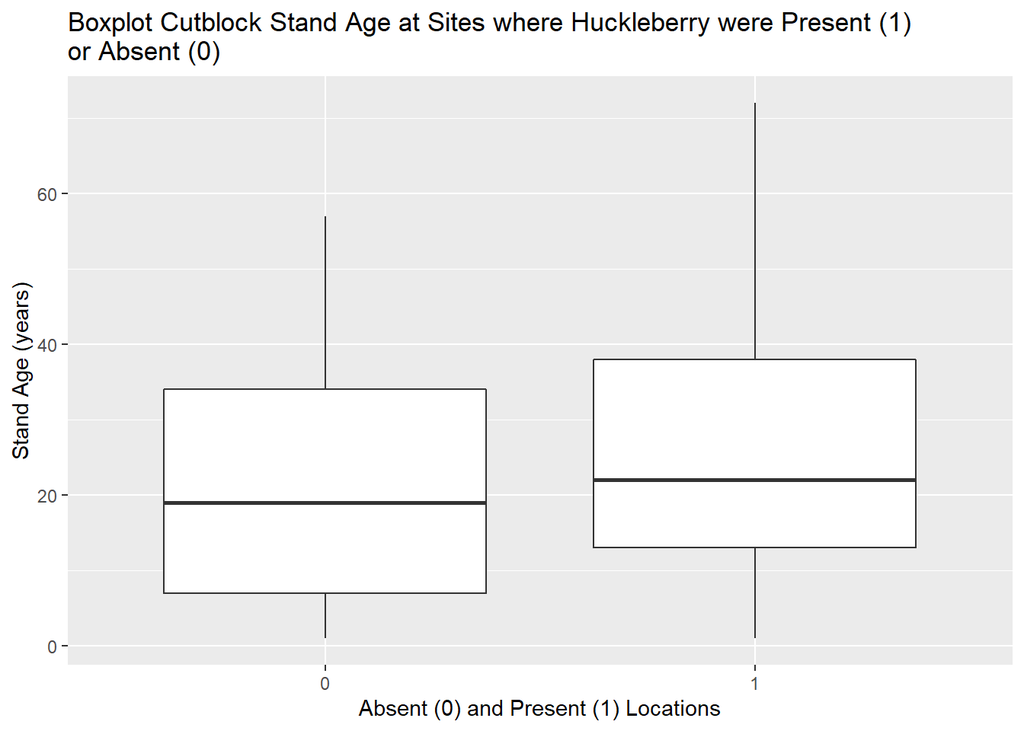

```r
data.prod.huck.na <-  data.prod.huck [Species.Present != ""] # drop NA values
data.prod.huck.na.cut <-  data.prod.huck.na [CutBlock_Occurrence == 1] # only harvested origins
data.prod.huck.na.cut$Species.Present <- as.factor (data.prod.huck.na.cut$Species.Present)

 ggplot (data.prod.huck.na.cut, aes (x = Species.Present, y = TimeSinceCut)) +
  geom_boxplot (outlier.colour = "red") +
  labs (title = "Boxplot Cutblock Stand Age at Sites where Huckleberry were Present (1)
or Absent (0)",
        x = "Absent (0) and Present (1) Locations",
        y = "Stand Age (years)")
```

Huckleberry cover was generally consistent across cutblock age.

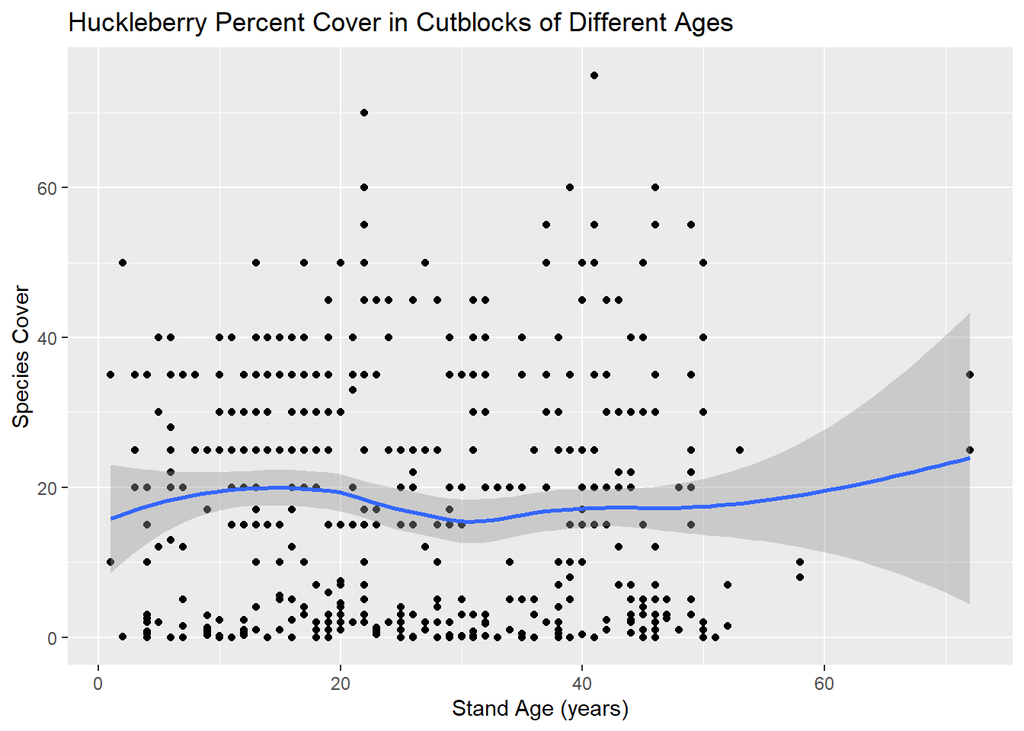

```r
 ggplot (data.prod.huck.na.cut, aes (x = TimeSinceCut, y = Species.Cover)) +
  geom_point () +
  geom_smooth () +
  labs (title = "Huckleberry Percent Cover in Cutblocks of Different Ages",
        x = "Stand Age (years)",
        y = "Species Cover")
```

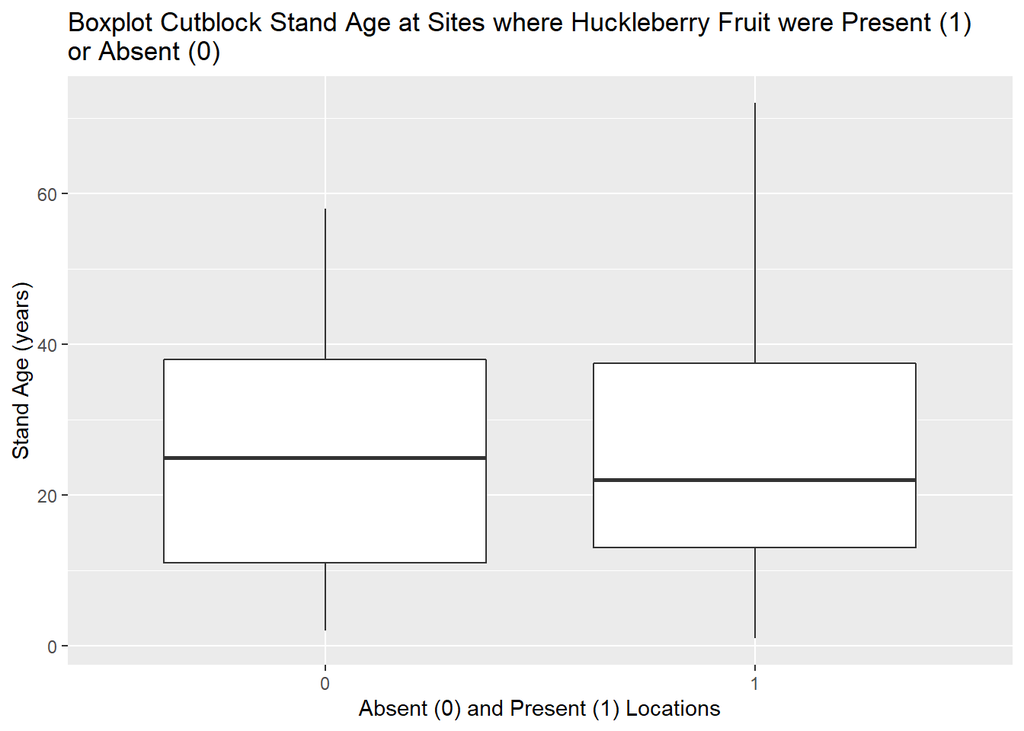

```r
data.prod.huck.fruit.na <-  data.prod.huck [Fruit.Present != ""] # drop NA values
data.prod.huck.fruit.na.cut <-  data.prod.huck.fruit.na [CutBlock_Occurrence == 1] # only harvested origins
data.prod.huck.fruit.na.cut$Fruit.Present <- as.factor (data.prod.huck.fruit.na.cut$Fruit.Present)

 ggplot (data.prod.huck.fruit.na.cut, aes (x = Fruit.Present, y = TimeSinceCut)) +
  geom_boxplot (outlier.colour = "red") +
  labs (title = "Boxplot Cutblock Stand Age at Sites where Huckleberry Fruit were Present (1)
or Absent (0)",
        x = "Absent (0) and Present (1) Locations",
        y = "Stand Age (years)")
```

Huckleberry fruit abundance was generally consistent across cutblock age, with some weak evidence for an increase between ages 20 and 40.

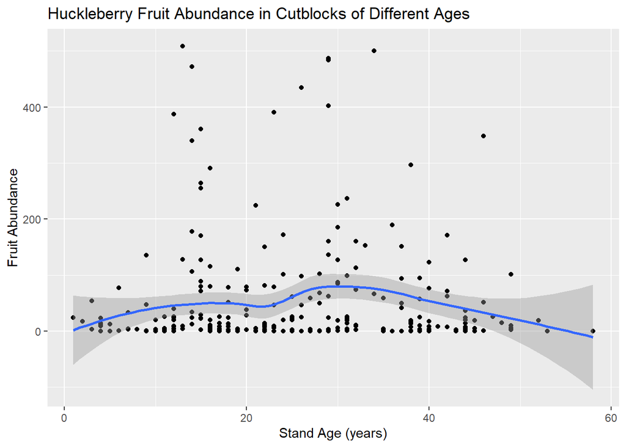

```r
data.prod.huck.fruit.na <-  data.prod.huck [Fruit.Abund != ""] # drop NA values
data.prod.huck.fruit.na.cut <-  data.prod.huck.fruit.na [CutBlock_Occurrence == 1] # only harvested origins

ggplot (data.prod.huck.fruit.na.cut, aes (x = TimeSinceCut, y = Fruit.Abund)) +
  geom_point () +
  geom_smooth () +
  labs (title = "Huckleberry Fruit Abundance in Cutblocks of Different Ages",
        x = "Stand Age (years)",
        y = "Fruit Abundance")
```

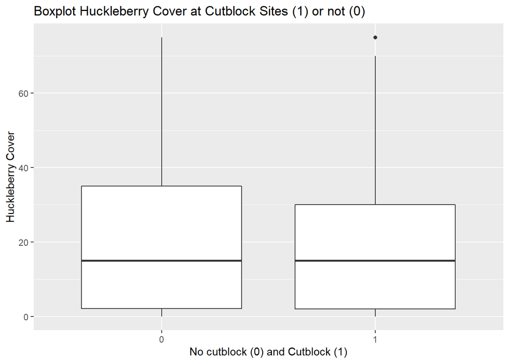

```r
data.prod.huck.na <-  data.prod.huck [Species.Present != ""] # drop NA values
data.prod.huck.na.cut <-  data.prod.huck [CutBlock_Occurrence != ""] # drop NA values
data.prod.huck.na.cut$CutBlock_Occurrence <- as.factor (data.prod.huck.na.cut$CutBlock_Occurrence)

ggplot (data.prod.huck.na.cut, aes (x = CutBlock_Occurrence, y = Species.Cover)) +
  geom_boxplot (data.prod.huck.na.cut = "red") +
  labs (title = "Boxplot Huckleberry Cover at Cutblock Sites (1) or not (0)",
        x = "No cutblock (0) and Cutblock (1)",
        y = "Huckleberry Cover")
```

Huckleberry fruit abundance was slightly less in cutblock origin stands than not.

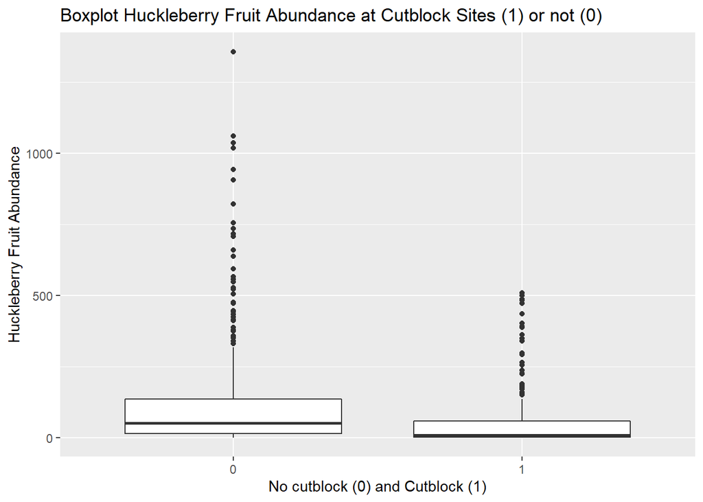

```r
data.prod.huck.na <-  data.prod.huck [Species.Present != ""] # drop NA values
data.prod.huck.na.cut <-  data.prod.huck [CutBlock_Occurrence != ""] # drop NA values
data.prod.huck.na.cut$CutBlock_Occurrence <- as.factor (data.prod.huck.na.cut$CutBlock_Occurrence)

ggplot (data.prod.huck.na.cut, aes (x = CutBlock_Occurrence, y = Fruit.Abund)) +
  geom_boxplot (data.prod.huck.na.cut = "red") +
  labs (title = "Boxplot Huckleberry Fruit Abundance at Cutblock Sites (1) or not (0)",
        x = "No cutblock (0) and Cutblock (1)",
        y = "Huckleberry Fruit Abundance")
```

Cutblock age may have a weak effect on huckleberry occurrence at a macro scale, but does not appear to affect huckleberry cover. Cutblock age did not appear to effect huckleberry fruit occurrence, but there may be a slight increase in fruit abundance in cutblocks 20 to 40 years old. Cutblocks may reduce huckleberry percent cover and fruit abundance.

##### Stand Age - Burns

Huckleberry were more likely to be detected in slightly older (~75 years old) than younger (~73 years old) burned stands.

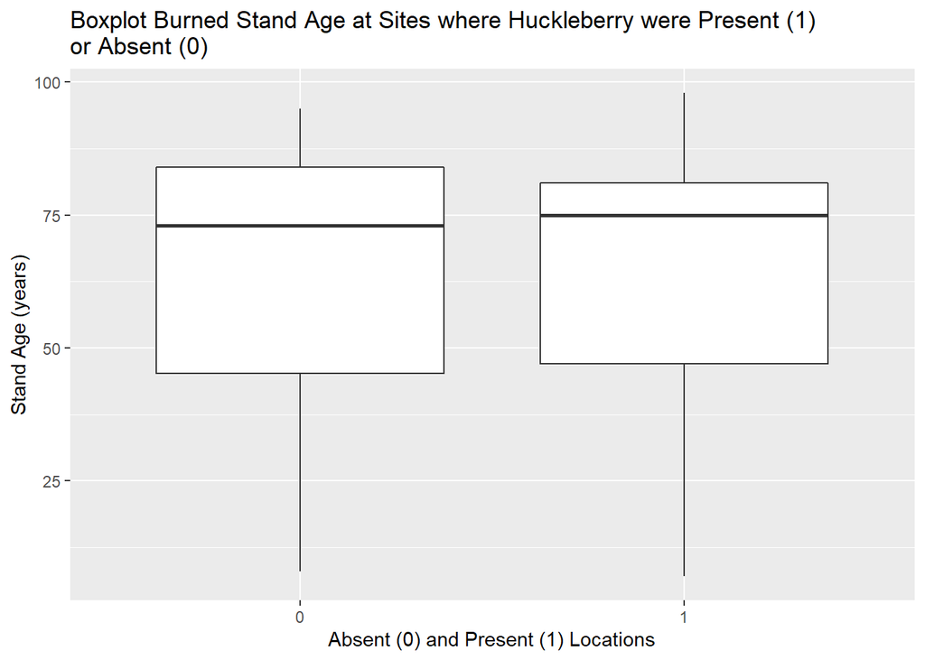

```r
data.prod.huck.na <-  data.prod.huck [Species.Present != ""] # drop NA values
data.prod.huck.na.fire <-  data.prod.huck.na [Fire_Occ == 1] # only harvested origins
data.prod.huck.na.fire$Species.Present <- as.factor (data.prod.huck.na.fire$Species.Present)

ggplot (data.prod.huck.na.fire, aes (x = Species.Present, y = TimeSinceFire
)) +
  geom_boxplot (outlier.colour = "red") +
  labs (title = "Boxplot Burned Stand Age at Sites where Huckleberry were Present (1)
or Absent (0)",
        x = "Absent (0) and Present (1) Locations",
        y = "Stand Age (years)")
```

Huckleberry cover was generally consistent across burn age.

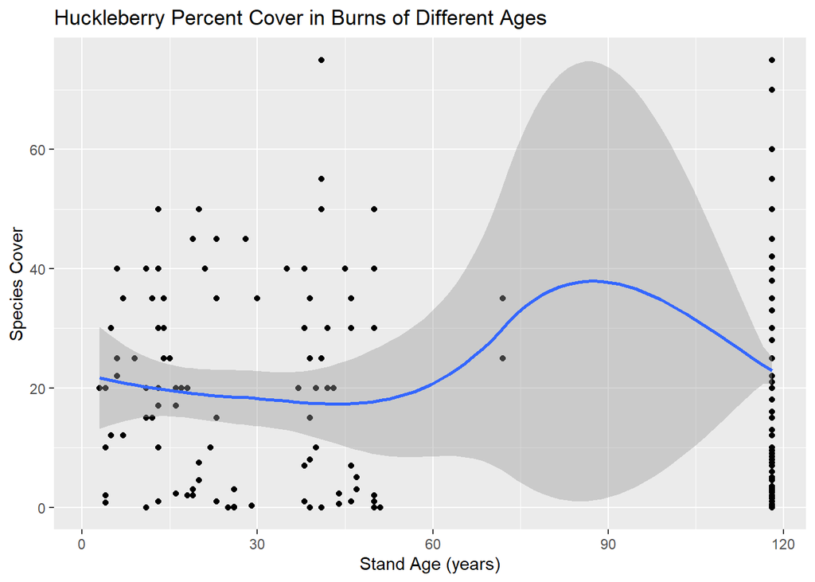

```r
 ggplot (data.prod.huck.na.fire, aes (x = TimeSinceCut, y = Species.Cover)) +
  geom_point () +
  geom_smooth () +
  labs (title = "Huckleberry Percent Cover in Burns of Different Ages",
        x = "Stand Age (years)",
        y = "Species Cover")
```

Huckleberry fruit ere more likely to be detected in slightly younger (~75 years old) than older (~78 years old) burned stands.

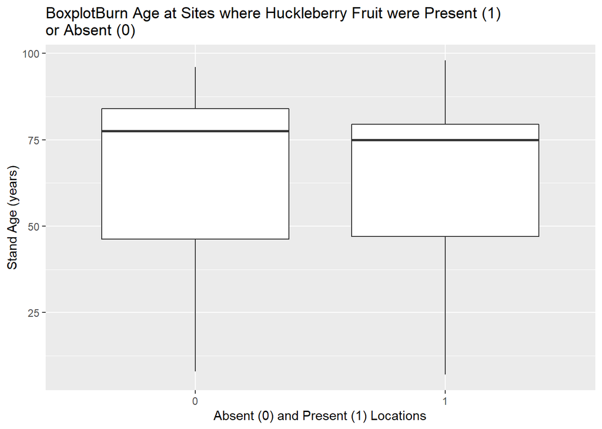

```r
data.prod.huck.fruit.na <-  data.prod.huck [Fruit.Present != ""] # drop NA values
data.prod.huck.fruit.na.fire <-  data.prod.huck.fruit.na [Fire_Occ == 1] # only harvested origins
data.prod.huck.fruit.na.fire$Fruit.Present <- as.factor (data.prod.huck.fruit.na.fire$Fruit.Present)

ggplot (data.prod.huck.fruit.na.fire, aes (x = Fruit.Present, y = TimeSinceFire)) +
  geom_boxplot (outlier.colour = "red") +
  labs (title = "BoxplotBurn Age at Sites where Huckleberry Fruit were Present (1)
or Absent (0)",
        x = "Absent (0) and Present (1) Locations",
        y = "Stand Age (years)")
```

Huckleberry fruit abundance appeared to peak at age 60, although the distribution of fruit abundance was highly variable at age 60.

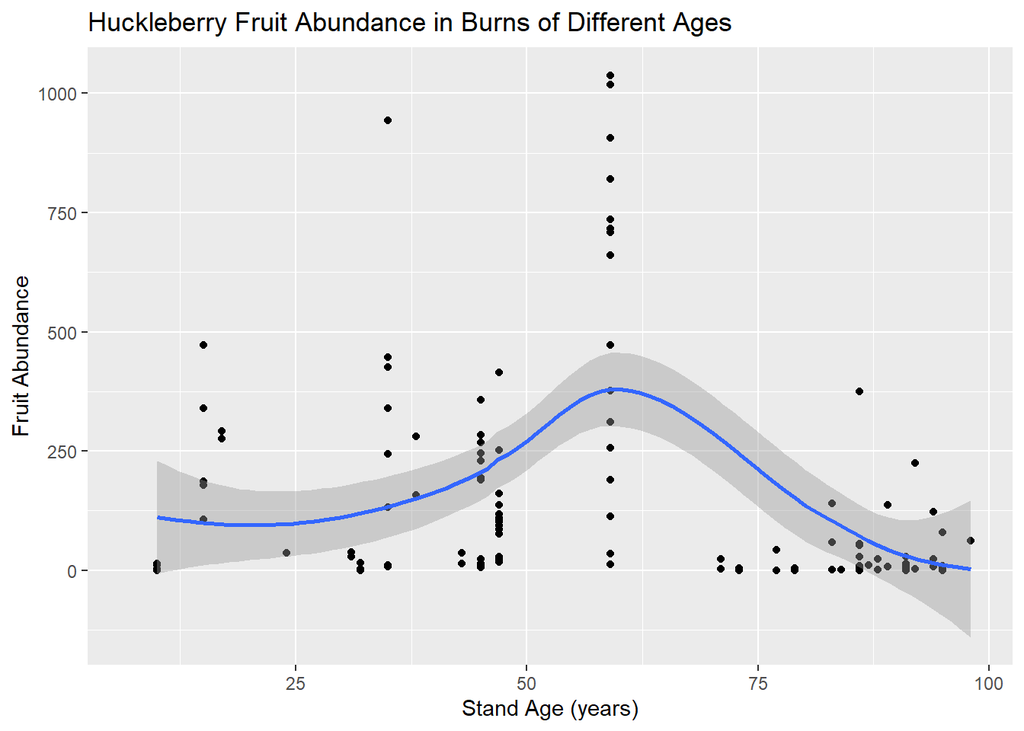

```r
data.prod.huck.fruit.na <-  data.prod.huck [Fruit.Present != ""] # drop NA values
data.prod.huck.fruit.na.fire <-  data.prod.huck.fruit.na [Fire_Occ == 1] # only harvested origins

ggplot (data.prod.huck.fruit.na.fire, aes (x = TimeSinceFire, y = Fruit.Abund)) +
  geom_point () +
  geom_smooth () +
  labs (title = "Huckleberry Fruit Abundance in Burns of Different Ages",
        x = "Stand Age (years)",
        y = "Fruit Abundance")
```

There was no notable effect of burn age on huckleberry occurrence at a macro scale. There was no notable evidence that burn age affected fruit occurrence, but there was some weak evidence that fruit abundance may peak in burned stands ~60 years old.

Huckleberry cover was slightly higher (~20) in fire origin stands than not (~15%).

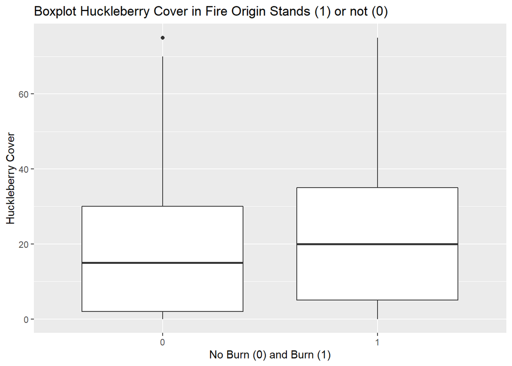

```r
data.prod.huck.na <-  data.prod.huck [Species.Present != ""] # drop NA values
data.prod.huck.na.fire <-  data.prod.huck [Fire_Occ != ""] # drop NA values
data.prod.huck.na.fire$Fire_Occ <- as.factor (data.prod.huck.na.fire$Fire_Occ)

ggplot (data.prod.huck.na.fire, aes (x = Fire_Occ, y = Species.Cover)) +
  geom_boxplot (data.prod.huck.na.fire = "red") +
  labs (title = "Boxplot Huckleberry Cover in Fire Origin Stands (1) or not (0)",
        x = "No Burn (0) and Burn (1)",
        y = "Huckleberry Cover")
```

Huckleberry fruit abundance was slightly higher in fire origin stands than not.

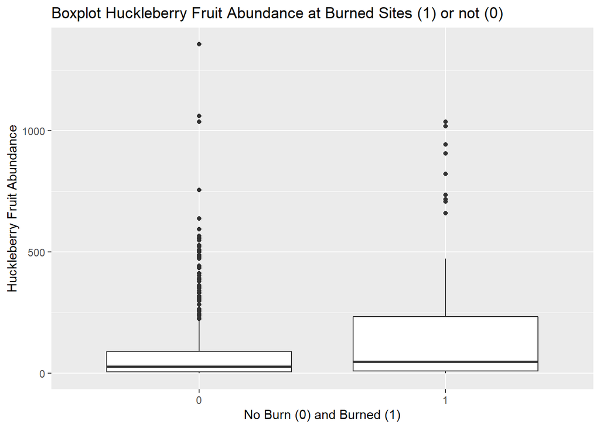

```r
data.prod.huck.na <-  data.prod.huck [Species.Present != ""] # drop NA values
data.prod.huck.na.fire <-  data.prod.huck [Fire_Occ != ""] # drop NA values
data.prod.huck.na.fire$Fire_Occ <- as.factor (data.prod.huck.na.fire$Fire_Occ)

ggplot (data.prod.huck.na.fire, aes (x = Fire_Occ, y = Fruit.Abund)) +
  geom_boxplot (data.prod.huck.na.fire = "red") +
  labs (title = "Boxplot Huckleberry Fruit Abundance at Burned Sites (1) or not (0)",
        x = "No Burn (0) and Burned (1)",
        y = "Huckleberry Fruit Abundance")
```

Overall, I don’t see compelling evidence that stand age, whether harvest or burn origin, influences huckleberry shrubs or fruit on those shrubs. However, there was some weak evidence that huckleberry cover and fruit abundance was less in harvest origin, but greater in fire origin stands.

It seems harvest and fire don’t appear to play a big role in huckleberry distribution or abundance, but the most promising models here are:

Huck<sub>occ</sub> = Cut<sub>age</sub>

##### Topographic

Below I explore distributions of topographic data for huckleberries.

Huckleberry were generally detected at higher (~1,750M) than lower (~1,250m) elevations.

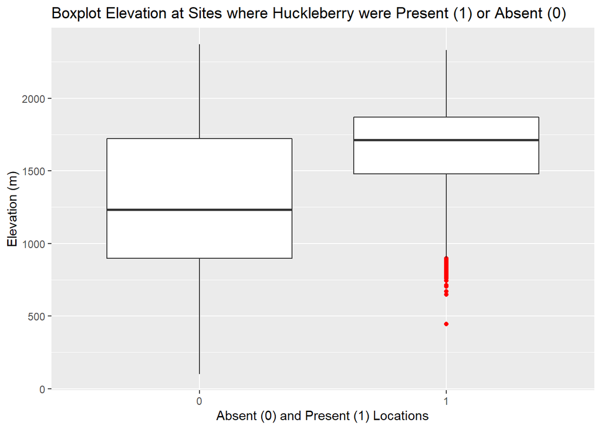

```r
data.prod.huck.na <-  data.prod.huck [Species.Present != ""] # drop NA values
# elevation, by species presence/absence
data.prod.huck.na$Species.Present <- as.factor (data.prod.huck.na$Species.Present)

 ggplot (data.prod.huck.na, aes (x = Species.Present, y = DEM_30_bcalb)) +
  geom_boxplot (outlier.colour = "red") +
  labs (title = "Boxplot Elevation at Sites where Huckleberry were Present (1) or Absent (0)",
        x = "Absent (0) and Present (1) Locations",
        y = "Elevation (m)")
```

Huckleberry cover was generally highest at intermediate-high (~1,850m) elevations.

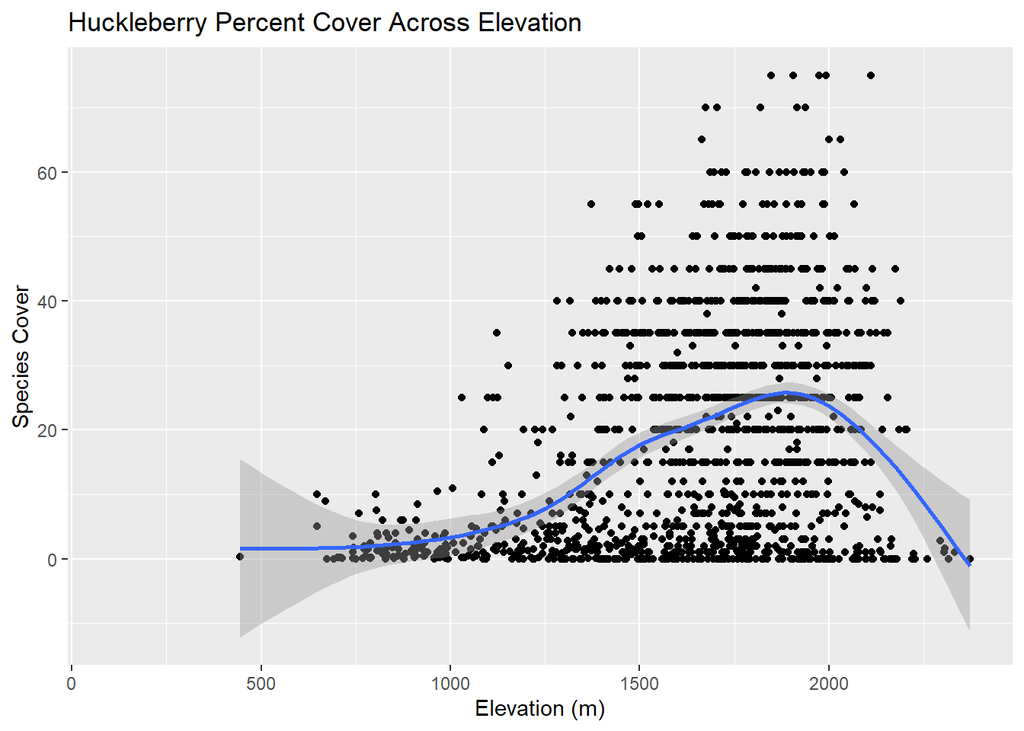

```r
data.prod.huck.na <-  data.prod.huck [Species.Present != ""] # drop NA values

 ggplot (data.prod.huck.na, aes (x = DEM_30_bcalb, y = Species.Cover)) +
  geom_point () +
  geom_smooth () +
  labs (title = "Huckleberry Percent Cover Across Elevation",
        x = "Elevation (m)",
        y = "Species Cover")
```

Elevation appears to be important for huckleberry occurrence and cover at macro scale, and is a quadratic relationship for cover.

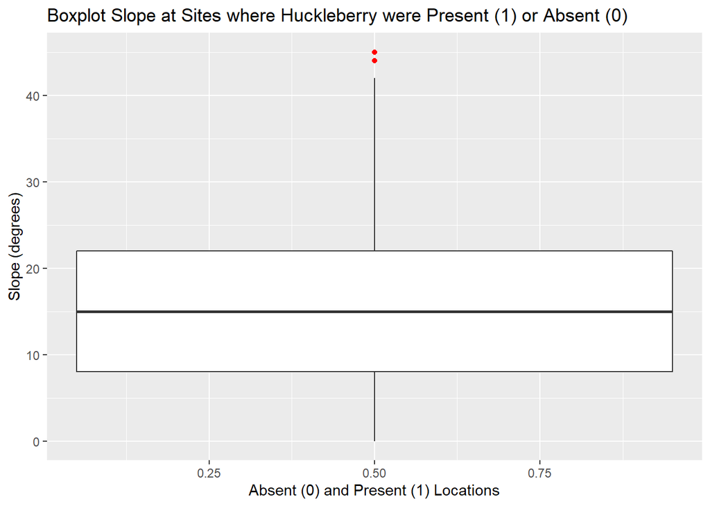

```r
# slope, by species presence/absence
 ggplot (data.prod.huck.na, aes (x = Species.Present, y = slope_30m_SRTM)) +
  geom_boxplot (outlier.colour = "red") +
  labs (title = "Boxplot Slope at Sites where Huckleberry were Present (1) or Absent (0)",
        x = "Absent (0) and Present (1) Locations",
        y = "Slope (degrees)")
```

Huckleberry cover was generally highest at intermediate (~20 degree) slopes.

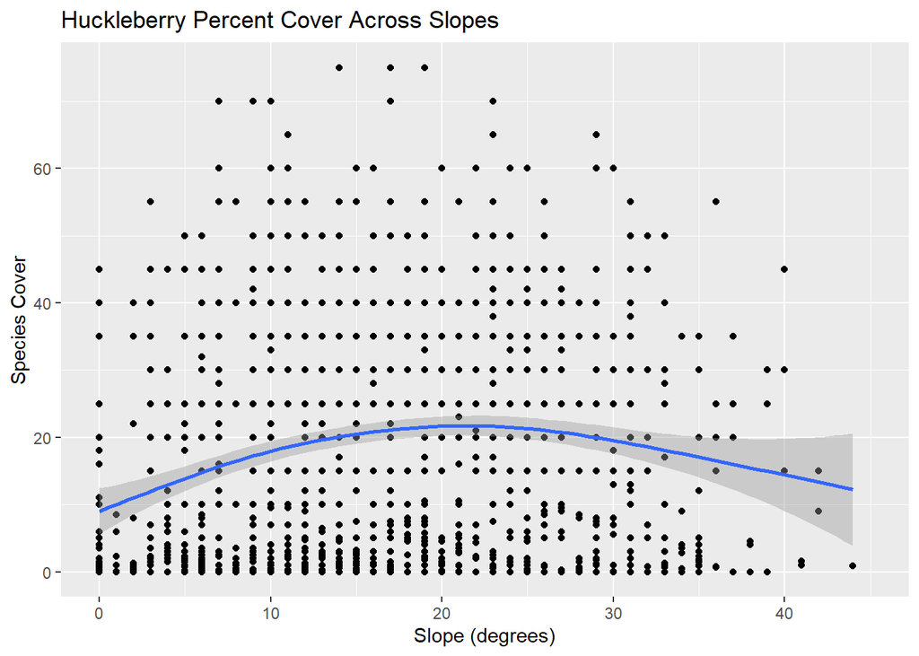

```r
 ggplot (data.prod.huck.na, aes (x = slope_30m_SRTM, y = Species.Cover)) +
  geom_point () +
  geom_smooth () +
  labs (title = "Huckleberry Percent Cover Across Slopes",
        x = "Slope (degrees)",
        y = "Species Cover")
```

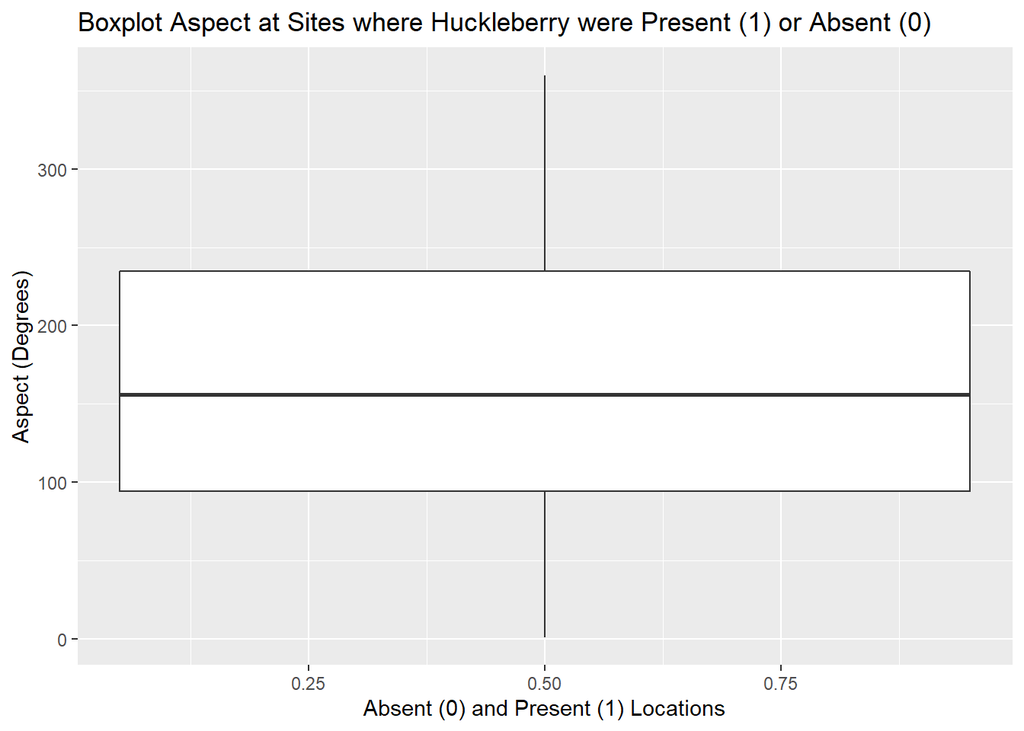

```r
 ggplot (data.prod.huck.na, aes (x = Species.Present, y = aspect_30m_SRTM)) +
  geom_boxplot (outlier.colour = "red") +
  labs (title = "Boxplot Aspect at Sites where Huckleberry were Present (1) or Absent (0)",
        x = "Absent (0) and Present (1) Locations",
        y = "Aspect (Degrees)")
```

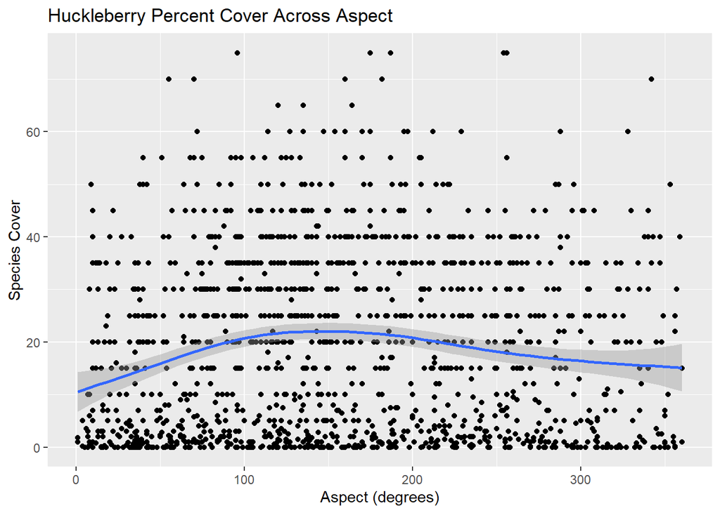

```r
 ggplot (data.prod.huck.na, aes (x = aspect_30m_SRTM, y = Species.Cover)) +
  geom_point () +
  geom_smooth () +
  labs (title = "Huckleberry Percent Cover Across Aspect",
        x = "Aspect (degrees)",
        y = "Species Cover")
```